# Introducción a la línea de comandos (Terminal) y la sintaxis de la lenguage R

# 1) Conceptos básicos de R

# 1.1) Pasos básicos

- Se puede acceder a R haciendo clic en un icono o ingresando el comando “R” en la línea de comando del sistema, también conocido como Terminal
- Esto produce una ventana de consola o hace que R se inicie como un programa interactivo en la ventana de terminal actual
- R funciona fundamentalmente mediante un modelo de preguntas y respuestas: ingrese una línea con un comando y presione Enter
- Entonces el programa hace algo relevante
- En este curso, usaremos RStudio y un formato de archivo llamado R Markdown, que nos permite codificar usando no solo R, sino bash y Python, otros dos lenguajes a los que podemos referirnos a medida que avanza el curso.

# 1.2) Biblioteca ISwR

- Todos los ejemplos en el libro utilizados como referencia deben ejecutarse siempre que la biblioteca ISwR no solo se instale sino que también se cargue en la ruta de búsqueda actual
- La biblioteca se puede instalar y cargar escribiendo el siguiente comando en un fragmento de R

```r
#install.packages ("ISwR")
package("ISwR")
```

- Para tener una primera impresión de lo que puede hacer R, intentemos trazar un gráfico.

# 1.3) Trazar números aleatorios

- Necesita insertar el fragmento R y usar la función de trazado

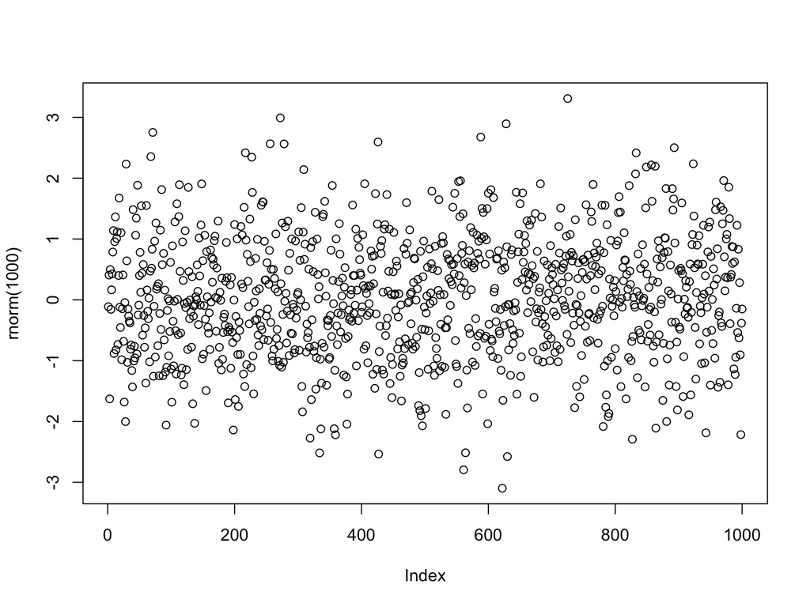

```r
plot(rnorm(1000))
```

# 1.4) Una calculadora potente

- R puede procesar expresiones aritméticas simples y complejas y producir un resultado para el usuario

```r
2 + 2
```

```
## [1] 4
```

- R también se puede utilizar para realizar otros cálculos estándar. Aquí se explica cómo calcular e elevado a -2

```r
exp (-2)
```

```
## [1] 0.1353353
```

- Aparte de los fragmentos R, estos cálculos se pueden realizar utilizando RStudio Console

# 1.5) Asignaciones

- Asignaciones realizadas en función de la necesidad de almacenar los resultados de los cálculos y utilizar estos resultados en los pasos de procesamiento posteriores en una tubería completa
- Como otros lenguajes, R tiene variables simbólicas: nombres que pueden usarse para representar valores
- Para asignar el valor 2 a la variable x, se puede ingresar

```r
x <- 2
```

- El carácter <- se llama operador de asignación
- No hay un resultado visible inmediato, pero a partir de ahora, x tiene el valor 2 y se puede utilizar en operaciones aritméticas posteriores.

# 1.6) Operaciones después de la asignación de variables

- A continuación, nuestra variable x, se utiliza para realizar otros cálculos.

```r
x
```

```
## [1] 2
```

```r
x + x ## Adición
```

```
## [1] 4
```

```r
5 * x ## Multiplicación
```

```
## [1] 10
```

```r
x ^ 3 ## Potenciación
```

```
## [1] 8
```

# 1.7) Aritmética vectorizada

- No es útil usar un número a la vez para ejecutar estadísticas
- Una ventaja de R es que puede manejar vectores de datos completos como objetos individuales
- Un vector de datos es una matriz de números y una variable de vector se puede construir así

```r
peso <- c (60, 72, 57, 90, 95, 72)
## Para ver la variable vectorial, simplemente escribe su nombre nuevamente
peso
```

```
## [1] 60 72 57 90 95 72
```

- Puede hacer cálculos con vectores como números ordinarios, siempre que tengan la misma longitud
- Una excepción a esta regla que veremos será cuando usamos la media de pesos de personas (representada por xbar)
- En ese caso, la media será un solo número, que se restará de cada valor de muestra

# 1.7) Aritmética vectorizada

- Suponga que el vector de peso indica el peso de los hombres en kilogramos.
- Una fórmula simple para indicar si una persona es obesa o no, es el índice de masa corporal (IMC)
- El IMC se calcula dividiendo el peso de la persona por el cuadrado de su altura, en metros.
- Por lo tanto, en R, necesitamos tener un vector con los valores de altura para calcular el vector bmi, que contenga el índice de masa corporal para los individuos indicados en el vector de peso.

```r
altura <- c (1.75, 1.80, 1.65, 1.90, 1.74, 1.91)
bmi <- peso / altura ^ 2
bmi
```

```
## [1] 19.59184 22.22222 20.93664 24.93075 31.37799 19.73630
```

# 1.8) Calcular la media de la variable peso

- La media se calcula mediante la suma de las observaciones dividida por el número total de observaciones.

$\overline{x}$ = $\sum x_i$ / n

- Calculemos la media de la variable peso

```r
sum(peso)
```

```
## [1] 446
```

```r
sum(peso) / length(peso)
```

```
## [1] 74.33333
```

# 1.9) Calcule la desviación estándar del peso variable

- La desviación estándar se puede calcular con la siguiente ecuación

$$SD = \sqrt{(\sum(x_i-\overline{x})^2)/(n-1)}$$

- xbar, la media del peso variable, se puede calcular utilizando la suma y la longitud del peso variable

```r
xbar <- sum(peso) / length(peso)
xbar
```

```
## [1] 74.33333
```

- Ahora podemos calcular la diferencia de cada réplica en la variable ponderación y la media de la variable ponderación, una por una

```r
peso - xbar
```

```
## [1] -14.333333  -2.333333 -17.333333  15.666667  20.666667  -2.333333
```

- Observe cómo R usa xbar, que tiene una longitud de uno, para calcular el nuevo peso - vector de datos xbar
- xbar se recicla y se resta de cada elemento en la variable de peso (vector de datos de peso)

# 1.10) Cálculo de la desviación estándar

- Calcular las desviaciones cuadradas

```r
(peso - xbar) ^ 2
```

```
## [1] 205.444444   5.444444 300.444444 245.444444 427.111111   5.444444
```

- Calcular la suma de las desviaciones al cuadrado

```r
sum ((peso - xbar) ^ 2)
```

```
## [1] 1189.333
```

- Calcular la desviación estándar

```r
sqrt(
  sum(
    (peso - xbar) ^ 2 /
      (length (peso) -1)
)
)
```

```
## [1] 15.42293
```

# 1.11) Procedimientos estadísticos estándar

- Es una práctica médica estándar para acceder si una persona es obesa o no utilizando criterios científicos validados
- Como procedimiento simple para mostrar este concepto, supongamos que una persona con un peso normal debe tener un IMC en el rango de 20-25.
- Queremos saber si nuestros datos se desvían del rango normal de IMC
- En R, esto se puede hacer usando una prueba estadística llamada prueba t
- No es necesario que comprenda qué es una prueba t, solo recuerde que se usa para evaluar la distribución de los valores de la muestra en comparación con la distribución normal
- Puede usar una prueba t de una muestra para evaluar si se puede suponer que el IMC de las seis personas tiene una media de 22,5 dado que provienen de una distribución normal
- Puedes hacerlo usando la función t.test

# 1.11) Procedimientos estadísticos estándar: prueba t

```r
t.test(
  bmi,
  mu = 22.5
)
```

```
##
##  One Sample t-test
##
## data:  bmi
## t = 0.34488, df = 5, p-value = 0.7442
## alternative hypothesis: true mean is not equal to 22.5
## 95 percent confidence interval:
##  18.41734 27.84791
## sample estimates:
## mean of x
##  23.13262
```

# 1.12) Gráficos de trama

- Tracemos ahora un diagrama de dispersión de la altura y el peso de los individuos.

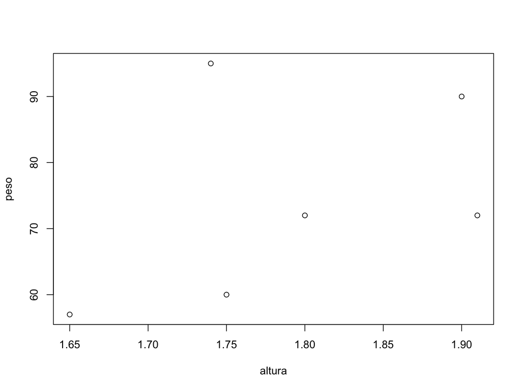

```r
plot (altura, peso)
```